# Project 5: Cross Tabs

Jeffrey Zhang and Jaclyn Nguyen

April 13, 2015

#### **1. Loading of R packages: RCurl, ggplot2, extrafont, jsonlite, dplyr, tidyr, extrafont, jsonlite, reshape2 (R code not shown)**

#### **2. Data**

Data that is provided for Project2 was selected from the Centers for Medicare and Medicaid Services (CMS). This center provides information about all health care services in America. In this project, Jeffrey and Jackie are focusing on Medicare Providers and the medical charges for outpatient services in 2012.

The data set can be found at [Medicare Provider Utilization and Payment Data: Outpatient](http://www.cms.gov/Research-Statistics-Data-and-Systems/Statistics-Trends-and-Reports/Medicare-Provider-Charge-Data/Outpatient.html)

```r
source("../03 Data/df.R",echo = T)
```

```
##
## > df <- data.frame(fromJSON(getURL(URLencode("129.152.144.84:5001/rest/native/?query=\"select * from medcharge\""),
## +     httpheader = c(DB = "jdbc:o ..." ... [TRUNCATED]
```

#### **3. Crosstabss created through SQL query in R**

The project requirements has requirements of displaying crosstabs using SQL query in R. The following crosstabs are rank, last value/max value & difference, nth value, and cumulative distribution.

**Crosstab #1: Rank**

```r
source("../01 SQL crosstabs/rank.R", echo=T)
```

```
##
## > rank <- data.frame(fromJSON(getURL(URLencode(gsub("\n",
## +     " ", "129.152.144.84:5001/rest/native/?query=\n\"select PROVIDER_STATE,AVERAGE_TOTAL_ .... [TRUNCATED]
##
## > head(rank)
##   PROVIDER_STATE AVERAGE_TOTAL_PAYMENTS PROVIDER_CITY STATE_RANK
## 1             AK                   1000        JUNEAU          1
## 2             AK                    982      SOLDOTNA          2
## 3             AK                    918     FAIRBANKS          3
## 4             AK                    901     ANCHORAGE          4
## 5             AK                    894        PALMER          5
## 6             AK                    845        JUNEAU          6
```

From Rank crosstab, we can clearly see the rank of a specific medicial payment(on AVG) in each state. For example, a $738 medical payment is on the 10th rank in AK state. Therefore, this crosstab is very useful for us to visulize the rank for a specific medical payment in each state.

**Crosstab #2: Last value/Max Value Difference**

```r
source("../01 SQL crosstabs/last_max_diff.R", echo=T)
```

```
##
## > difference <- data.frame(fromJSON(getURL(URLencode(gsub("\n",
## +     " ", "129.152.144.84:5001/rest/native/?query=\n\"select APC, Provider_State, Ou .... [TRUNCATED]
##
## > head(difference)
##                                            APC PROVIDER_STATE
## 1 0012 - Level I Debridement  and  Destruction             AK
## 2 0012 - Level I Debridement  and  Destruction             AR
## 3 0012 - Level I Debridement  and  Destruction             AR
## 4 0012 - Level I Debridement  and  Destruction             AR
## 5 0012 - Level I Debridement  and  Destruction             AR
## 6 0012 - Level I Debridement  and  Destruction             AR
##   OUTPATIENT_SERVICES MAX_SERVICES1 SERVICE_DIFFERENCE
## 1                1053         25502              24449
## 2                  23         25502              25479
## 3                3314         25502              22188
## 4                 352         25502              25150
## 5                  19         25502              25483
## 6                  64         25502              25438
```

**Crosstab #3: Nth Value**

```r
source("../01 SQL crosstabs/nth_value.R", echo=T)
```

```
##
## > nth_value <- data.frame(fromJSON(getURL(URLencode(gsub("\n",
## +     " ", "129.152.144.84:5001/rest/native/?query=\n\"select PROVIDER_STATE,AVERAGE_T .... [TRUNCATED]
##
## > head(nth_value)
##   PROVIDER_STATE AVERAGE_TOTAL_PAYMENTS PROVIDER_CITY
## 1             AK                   1000        JUNEAU
## 2             AK                    982      SOLDOTNA
## 3             AK                    918     FAIRBANKS
## 4             AK                    901     ANCHORAGE
## 5             AK                    894        PALMER
## 6             AK                    845        JUNEAU
##   NTH_AVG_TOTAL_PAYMENTS
## 1                    982
## 2                    982
## 3                    982
## 4                    982
## 5                    982
## 6                    982
```

From this nth_value crosstab, we can clearly see the nth value of the medical payment (on AVG) in each state as we want. For exmaple, if we want to see the fifth value of the medicial payment in each state, we can put 5 in the nth_value parameter.

**Crosstab #4: Cumulative Distribution**

```r
source("../01 SQL crosstabs/cumediff.R", echo=T)
```

```
##
## > cumediff <- data.frame(fromJSON(getURL(URLencode(gsub("\n",
## +     " ", "129.152.144.84:5001/rest/native/?query=\n\"select APC, Provider_State, Outp .... [TRUNCATED]
##
## > head(cumediff)
##                                            APC PROVIDER_STATE
## 1 0012 - Level I Debridement  and  Destruction             WV
## 2 0012 - Level I Debridement  and  Destruction             WV
## 3 0012 - Level I Debridement  and  Destruction             WI
## 4 0012 - Level I Debridement  and  Destruction             WI
## 5 0012 - Level I Debridement  and  Destruction             WI
## 6 0012 - Level I Debridement  and  Destruction             WI
##   OUTPATIENT_SERVICES CUME_DIST
## 1                 168 0.5451713
## 2                 757 0.7352025
## 3                 743 0.7320873
## 4                 655 0.7196262
## 5                  12 0.0623053
## 6                 593 0.7133957
```

The crosstab created here shows the cumulative distribution of outpatient services partitioned by APC. Our sample figure above shows that in 0012 - Level I Debridement and Destruction, West Virginia has a provider that had 168 outpatient services which is equivalent to 54.4% distribution of the total outpatient services in APC 0012.

## **4. Crosstabs created through Tableau**

Below are sample crosstabs created in Tableau.

##### **Rank Crosstab**

This crosstab will show the rankings of average payment cost, broken down by state and city descending.

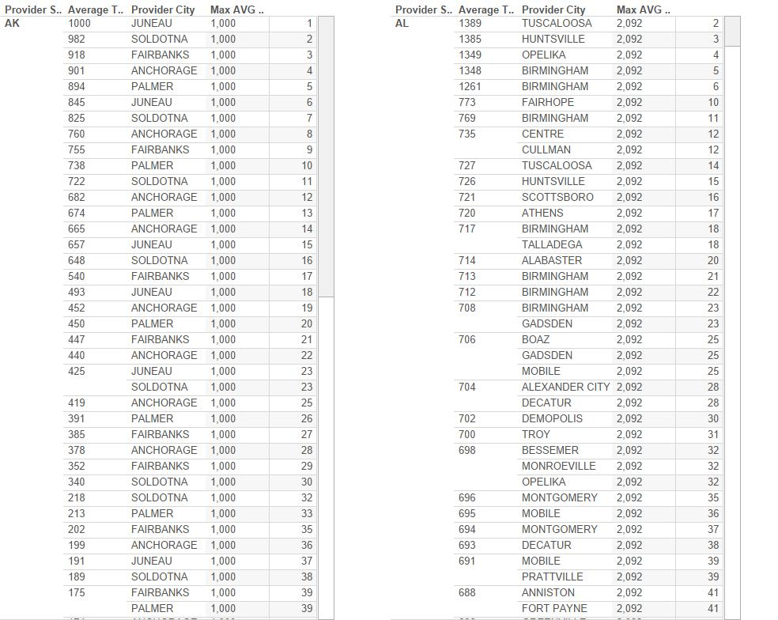

##### **Last Value/Max Value and their Differences Crosstab**

This will show the current value, max value, and their differences for two states.

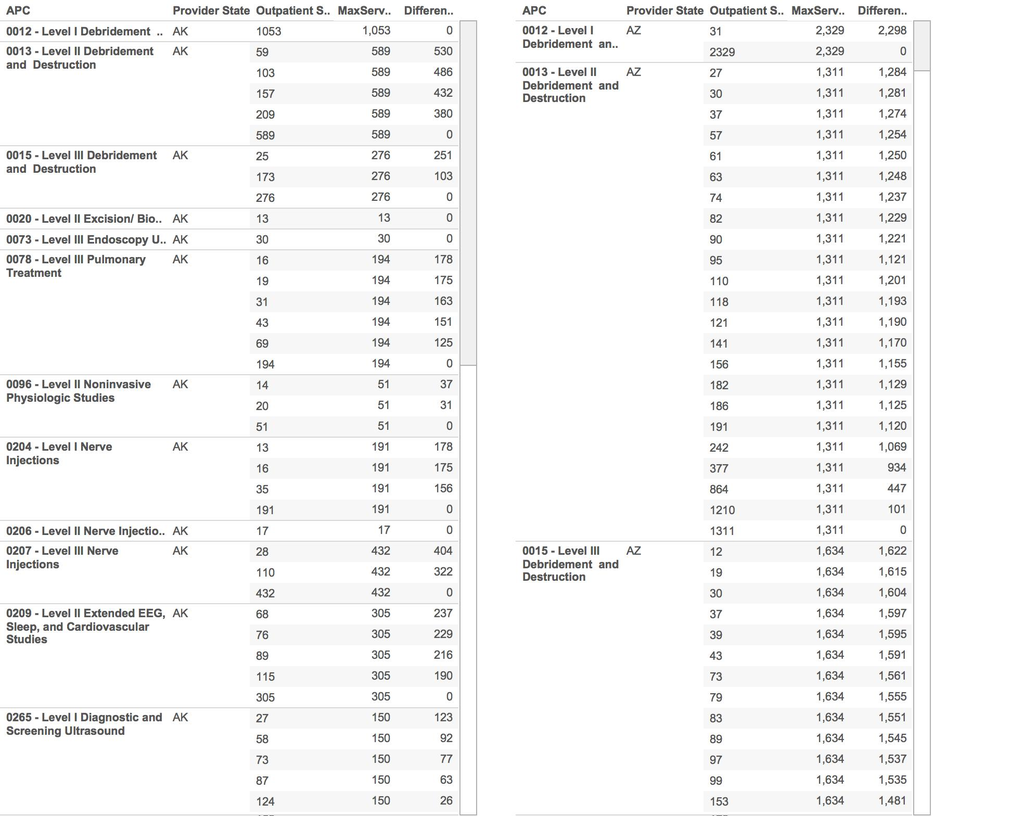

##### **Nth_value Crosstab**

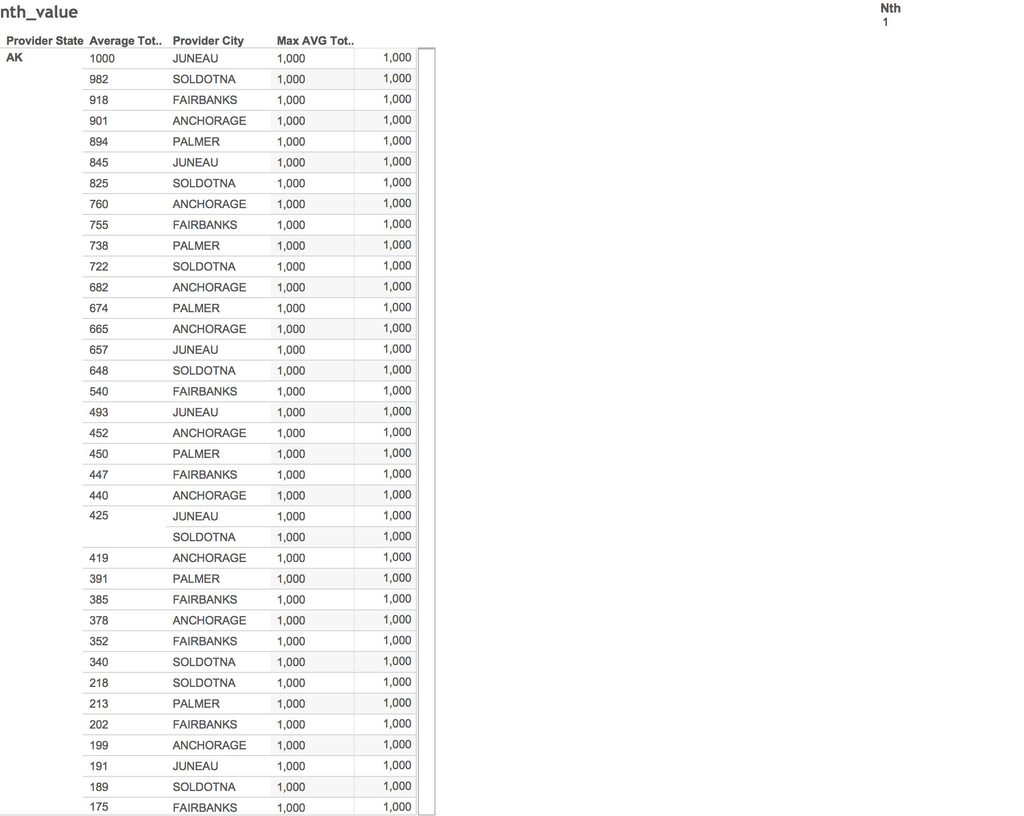

##### **Cumulative Distribution Crosstab**

Cumulative distribution among the outpatient services based on APC

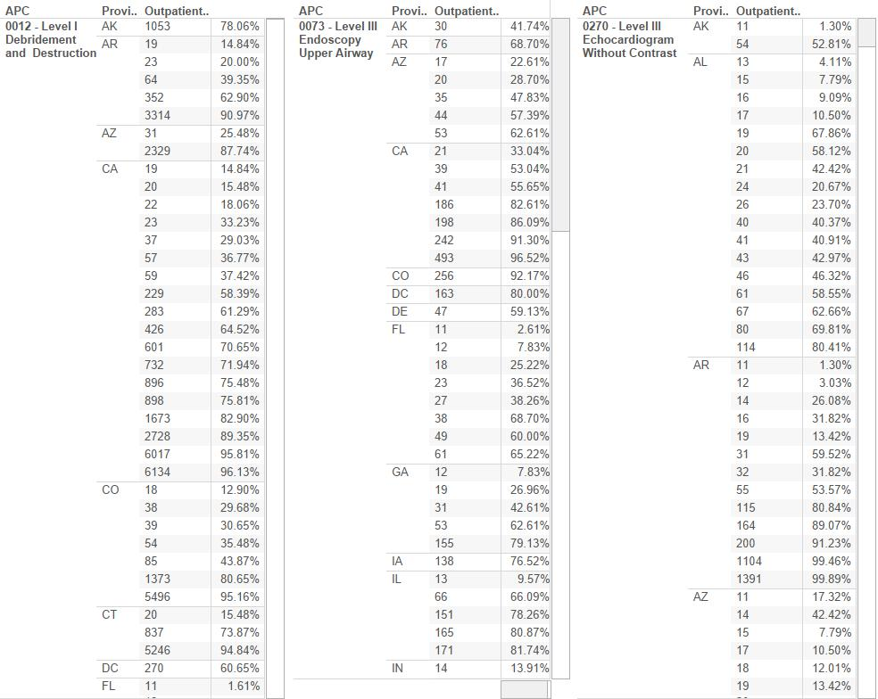